# Class 9: Politically Violent Activity

Escalation and restraint

[Dr. Michael C. Zeller](https://michaelzeller.de)

# Opening notes

[Open Sticker](https://tenor.com/view/open-gif-14209777)from [Open Stickers](https://tenor.com/search/open-stickers)

## Presentation groups

Presentations line-up

| Date | Presenters | Method |
| --- | --- | --- |
| 4 Dec: | Shahadaan, Kristine, Daichi | ethnography |
| 11 Dec: | Bérénice, Zorka, Victoria, Katharina | content analysis |
| 18 Dec: | Shoam, Aidan, Tara, Sebastian | QCA |

# Antifa

- opening discussion
- debatable proposition and pressing policy issue
- antifa in Germany
- Copsey and Merrill (2020): antifa in the U.S.

[Revolution Antifa GIF](https://tenor.com/view/revolution-antifa-riot-black-block-anarchy-gif-1459673259347829360)from [Revolution GIFs](https://tenor.com/search/revolution-gifs)

## Opening discussion

**What should we, students of political violence, know about *antifa*? (causes? organisation/leadership? radical subcultures and mobilisation? strategies?)**

**is antifa a ‘gang’ (Pyrooz and Densley 2018)? is antifa a ‘group’ (LaFree 2018)?**

- gang - ‘durable and street-oriented youth group whose involvement in illegal activity is part of its group identity’ (Pyrooz and Densley 2018, 230)
- group - ‘some stable organisation that persists over time and has some discernible leadership structure’ (LaFree 2018, 249), see also GTF database: https://www.start.umd.edu/gtd/

## Debatable proposition: antifa as terrorist org.?

**Pyrooz and Densley (2018, 233): “the history of antifa reads like a history of violence”**

**vs.**

**Bray (2017, 169): “In truth, violence represents a small though vital sliver of anti-fascist activity.”**

**Should state security (in Germany, elsewhere) designate antifa as *extremist/terrorist***

## antifa (recently) in Germany

ARD series (in German): https://www.ardaudiothek.de/sendung/die-fascho-jaegerin-der-fall-lina-e-und-seine-folgen/94838298/

- 28-year-old antifa activist, Lina E., and three accomplices jailed for either membership of or support for a criminal organisation.
  - politicised/radicalised by revelations about NSU in 2011
- attacks on (assumed) right-wing extremists in Thüringen and Sachsen between 2018 and 2020
- judge…
  - acknowledged deficiency of criminal punishment of neo-Nazis
  - described right-wing extremism as a greater threat to Germany
  - but asserted ‘even Nazis have inalienable rights’
  - criticized the defense lawyers for describing the trial as “political justice.”

recent journal article: Jones and Schuhmacher (2024)

## Copsey and Merrill (2020) - background

- Since 2001, right-wing extremists in the U.S. responsible for 110 politically motivated deaths — antifa: 0 (or maximum one, in case of 2020 death of Patriot Prayer supporter)

> In putting their “bodies on the line,” militant anti-fascists aspire to defeat fascist organizing, to de-stabilize it, and ultimately de-mobilize it. At its root, anti-fascist militancy is the promise to effect intimidation, humiliation and de-moralization upon fascists. This involves a physical commitment to “no platforming” (p. 124)
- lots of informative background information about U.S. antifa in the article

## Copsey and Merrill (2020) - research design

- semi-structured interviews with activists from RCA in Portland
  - conditions of anonymity
  - between October 2019 and February 2020.
- sample of 3971 tweets (including 2484 retweets) shared by RCA’s Twitter account (@RoseCityAntifa)
  - between 13 March 2018 and 28 August 2019
  - collected using *Tweepy* in accordance with Twitter’s regulations
  - ‘more militant’ tweets—“648 tweets (including 279 retweets) from within this sample which featured variants of “violence,” “attack,” “assault,” “fight,” and “terror””
    - close reading; quantitatively and qualitatively analysed with critical discourse analysis approach

## Copsey and Merrill (2020) - findings/points raised

- violent disruption of “fascist” assembly is an axiom of antifa praxis
- how far does the label ‘fascist’ extend?
  - “*legitimacy of anti-fascist action is thus drawn from the illegitimacy of its opponent*”
- antifa’s “pre-emptive self-defence”
  - premised on (a) deadliness of fascist movements of any size and (b) rapid growth potential of fascist movements
- there are ‘*internal* tactical and rhetorical strategies that *limit* violence’ from antifa — BUT, consistent danger of antifa slipping into glorification of violence

# Poll: escalation and restraint

[figure not shown]

Take the survey at **https://forms.gle/12tV7fgjcAyC8iVG6**

- ideology secondary to pragmatic issues in choosing to use violence?
- most important in allowing *restraint*?
- most likely to provoke *escalation*?
- should states remain open to negotiating with violent groups?
- groups more likely to escalate violence if they feel they are losing support?

Questions about groups: (1) How does the group’s use of violence evolve over time? (2) How are major acts of violence perpetrated? (3) Does the group show restraint in choosing targets? (4) Is the group’s restraint more strategic or moral? (5) Does the group have internal mechanisms to prevent uncontrolled violence? (6) Does the group escalate violence in response to state actions?

[interactive chart not shown]

ideology secondary to pragmatic issues?

[interactive chart not shown]

more likely to escalate if losing support?

[interactive chart not shown]

## Poll results: escalation and restraint

most important factor allowing *restraint*?

[interactive chart not shown]

most likely to provoke *escalation*?

[interactive chart not shown]

## Poll results: negotiation

states should remain open to negotiating with politically violent groups?

[interactive chart not shown]

relates to our Week 11-12 classes on state responses

# Mechanisms of escalation and restraint

- escalation and restraint concepts
- catalogue of mechanisms
- grouped/summarised mechanisms
  - restraint
  - escalation

[Escalated Quickly Anchorman GIF](https://tenor.com/view/escalated-quickly-anchorman-drinking-gif-5112090)from [Escalated Quickly GIFs](https://tenor.com/search/escalated+quickly-gifs)

## escalation and restraint

- **escalation** - a rise in the frequency and/or severity of violent actions
- **restraint** - a deliberate restriction (either reducing or completely stopping) of violent actions

are there significant examples of escalation and/or restraint in cases you know of?

## Mechanisms of escalation and restraint

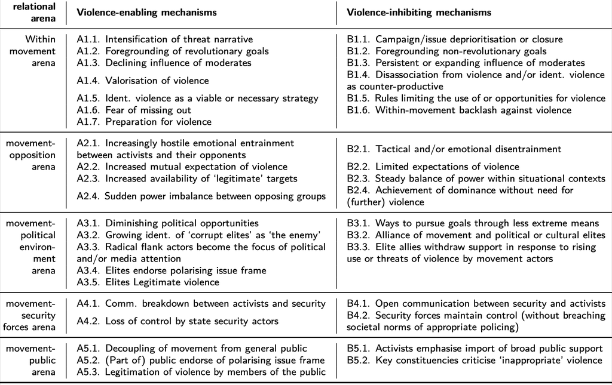

## summarising logics of restraint - (Busher et al. 2022; Bjørgo and Ravndal 2020)

(‘ascending the ladder of abstraction,’ Sartori 1970)

1. A **strategic logic** (violence is counterproductive in the present circumstances)
2. A **moral logic** (certain forms of violence are illegitimate)
3. A **logic of ego maintenance** (we are not a violent organization)
4. A **logic of outgroup definition** (softening views on putative outgroups)
5. An **organisational logic** (the organisation evolves in ways that undermine the logics of violent escalation)

## summarising logics of escalation - Busher et al. (2022)

(‘ascending the ladder of abstraction,’ Sartori 1970)

1. **framing logic** (intensity of context/threat, revolutionary goals, glorification of violence, violence as viable/necessary, increasing vilification of ‘enemies’)
2. **strategic logic** (cope with changing dynamics with opponents and/or state, deal with diminishing opportunity, loss of state control)
3. **organisational logic** (declining moderate influence, logistical/practical preparation for violence)
4. **constituency/social logic** (endorsement/legitimation from elites and/or public, politics/media focuses on radical flank)

## Group responses - violence over time

How does the group’s use of violence evolve over time?

[interactive chart not shown]

## Group responses - characteristic violence

Major acts of violence are typically…

[interactive chart not shown]

## Group responses - restraint

group demonstrates restraint in choosing targets?

[interactive chart not shown]

restraint is more often strategic than moral.

[interactive chart not shown]

## Group responses - breaks and accelerators

group has internal mechanisms to prevent uncontrolled violence?

[interactive chart not shown]

group escalates primarily responding to state action.

[interactive chart not shown]

# Open data - Profiles of Radicalisation

- Visualisation
- Explanatory note
- Data table

Violent Outcomes Across Ideological Movements

[interactive chart not shown]

This visualisation is based on a subset of the [Profiles of Individual Radicalization in the United States](https://www.start.umd.edu/data-tools/profiles-individual-radicalization-united-states-pirus) (PIRUS) dataset. It compares the proportion of individuals who engaged in violent extremist activities across different ideological milieus.

**National Consortium for the Study of Terrorism and Responses to Terrorism (START), University of Maryland. (2024). Profiles of Individual Radicalization in the United States (PIRUS) [Data file]. Retrieved from http://www.start.umd.edu/data-tools/profiles-individual-radicalization-united-states-pirus. Copyright University of Maryland 2024.**

| ideology | violent_cases | total_cases | violent_share |
| --- | --- | --- | --- |
| Far Left | 225 | 556 | 0.404676258992806 |
| Far Right | 1196 | 1926 | 0.620976116303219 |
| Islamist | 425 | 592 | 0.717905405405405 |
| Other | 0 | 1 | 0 |
| Single Issue | 234 | 453 | 0.516556291390728 |

# A case of RWE restraint?

- Nordic Resistance Movement (NRM) at a glance
- Tore Bjørgo on NRM
  - findings

[Restraint GIF](https://tenor.com/view/restraint-restraining-oder-elf-restrain-yourself-gif-13416157)from [Restraint GIFs](https://tenor.com/search/restraint-gifs)

## NRM at a glance

- Territory of action: Scandinavia [Blomberg and Stier (2019); ]
- Organisational structure: hierarchical national branches
- Membership: moderate (varies by country, e.g., Stiftelsen Expo 2025)
- (main) Objective: white ethno-state
- (common) Targets: political and ethnic opponents

[figure not shown]

- Repertoire of actions: low-level violence, connected to terrorism (e.g., Finland, Ravndal 2020; Kotonen 2021; Zeller and Vaughan 2024)

## Nordic Resistance Movement (NRM) - Tore Bjørgo

**Tore Bjørgo** on Why the Nordic Resistance Movement Restrains its Use of Violence (Bjørgo and Ravndal 2020)

[video not shown]

## Nordic Resistance Movement (NRM) - Tore Bjørgo

1. *When, why does NRM permit use of violence*?
   - no **moral restraints**, rather violence perceived as **counter-productive** (to gaining support and freely propagating views)
   - try to **expand boundaries of acceptable violence** with acts against police and political enemies
2. *Why, how does NRM restrain use of violence*?
   - to maintain **strategic position**
   - commit members to **maintaining nonviolent discipline**
3. *How does NRM leadership respond to cases where members overstep and act violently*?
   - **honouring** rather than **punishing** activists who overstep
   - BUT ALSO **distancing** from any affiliation or connection

# Any questions, concerns, feedback for this class?

Anonymous feedback here: https://forms.gle/NfF1pCfYMbkAT3WP6

Alternatively, please send me an email: m.zeller@lmu.de

Questions about groups next meeting: (1) Does the group try to grow its popular support? (2) Does the group’s violence increase local support for it? (3) What type of participation does the group most rely on? (4) Do most civilians in areas where the group is active support the group? (5) Does the group provide services (security, justice, welfare) that generate legitimacy?

## References

Bjørgo, Tore, and Jacob Aasland Ravndal. 2020. “Why the Nordic Resistance Movement Restrains Its Use of Violence.” *Perspectives on Terrorism* 14 (6): 37–48.

Blomberg, Helena, and Jonas Stier. 2019. “Flashback as a Rhetorical Online Battleground: Debating the (Dis)guise of the Nordic Resistance Movement.” *Social Media + Society* 5 (1): 205630511882333. https://doi.org/10.1177/2056305118823336.

Bray, Mark. 2017. *Antifa: The Anti-Fascist Handbook*. New York: Melville House Publishing. https://doi.org/10.1017/CBO9781107415324.004.

Busher, Joel, Gareth Harris, Julia Ebner, Zsofia Hacsek, and Graham Macklin. 2022. “The Dynamics Of Violence Escalation And Inhibition During ’Hot Periods’ Of Anti-Minority And Far-Right Activism: Towards An Assessment Framework.” Coventry: CREST.

Copsey, Nigel, and Samuel Merrill. 2020. “Violence and Restraint Within Antifa: A View from the United States.” *Perspectives on Terrorism* 14 (6): 122–38.

Jones, Ali, and Nils Schuhmacher. 2024. “Ghostly Militanz: The Loss of Discursive Infrastructures and German Antifascist Radical Counterpublics” 17 (1): 46–63. https://doi.org/10.1285/I20356609V17I1P46.

Kotonen, Tommi. 2021. “Proscribing the Nordic Resistance Movement in Finland: Analyzing the Process and Its Outcome.” *Journal for Deradicalization* 29 (Winter): 177–204.

LaFree, Gary. 2018. “Is Antifa a Terrorist Group?” *Society* 55 (3): 248–52. https://doi.org/10.1007/s12115-018-0246-x.

Pyrooz, David C., and James A. Densley. 2018. “On Public Protest, Violence, and Street Gangs.” *Society* 55 (3): 229–36. https://doi.org/10.1007/s12115-018-0242-1.

Ravndal, Jacob Aasland. 2020. “The Emergence of Transnational Street Militancy: A Comparative Case Study of the Nordic Resistance Movement and Generation Identity.” *Journal for Deradicalization* 25: 1–34.

Sartori, Giovanni. 1970. “Concept Misformation in Comparative Politics.” *The American Political Science Review* 64 (4): 1033–53.

Stiftelsen Expo. 2025. “Svensk Rasideologisk Miljö 2024.” Stokholm: Stiftelsen Expo.

Zeller, Michael C, and Michael Vaughan. 2024. “Proscribing Right-Wing Extremist Organizations in Europe: Variations, Trends, and Prospects.” *Terrorism and Political Violence* 36 (8): 985–1007. https://doi.org/10.1080/09546553.2023.2240446.